# Proyecto Final - Econometria en R

Ricardo Farfan - 21003210 , Rodrigo Solis - 21002223, Gabriela Subuyu - 21001134

Ricardo Farfan, Rodrigo Solis, Gabriela Subuyu

05 de July de 2026

# 1 Contexto del proyecto

El objetivo es predecir `SalePrice`, precio de venta de viviendas en Ames, Iowa. Utilizando como metrica principal el **RMSE**.

```r
# Cargamos las librerias a utilizar
library(dplyr)
library(ggplot2)
```

# 2 Carga de datos

```r
base  <- "DATASETS"
train <- read.csv(file.path(base, "data_train_v3.csv"), stringsAsFactors = FALSE)
test  <- read.csv(file.path(base, "test_v3.csv"),       stringsAsFactors = FALSE)

# Verificación de dimensiones.
cat("Entrenamiento:", nrow(train), "filas x", ncol(train), "columnas\n")
```

```
## Entrenamiento: 880 filas x 81 columnas
```

```r
cat("Prueba       :", nrow(test),  "filas x", ncol(test),  "columnas\n")
```

```
## Prueba       : 220 filas x 80 columnas
```

Los datasets de training y testing tienen una unica columna de diferencia que es SalesPrice, la cual es la que tenemos que predecir.

```r
# Mostrando la variable SalesPrice que es la diferencia entre los dataasets
setdiff(names(train), names(test))
```

```
## [1] "SalePrice"
```

# 3 Estructura general de las variables

```r
# Clasificamos las columnas por tipo entender que hacer en el preprocesamiento.
# Distinguir numéricas y categóricas
tipos <- sapply(train, class)
data.frame(
  tipo = c("numéricas (int/num)", "categóricas (character)"),
  n    = c(sum(tipos %in% c("numeric", "integer")),
           sum(tipos == "character"))
)
```

```
##                      tipo  n
## 1     numéricas (int/num) 38
## 2 categóricas (character) 43
```

Tenemos 38 variables numéricas y 43 categóricas. Al tener varias variables categóricas indica que vamos a tener que codificarlas antes de hacer los modelos.

```r
summary(train$SalePrice)
```

```
##    Min. 1st Qu.  Median    Mean 3rd Qu.    Max.
##   34900  131500  165800  181520  215000  755000
```

```r
# Calculamos la asimetría.
skewness <- function(x) {
  x <- x[!is.na(x)]
  mean((x - mean(x))^3) / (sd(x)^3)
}
cat("Asimetría de SalePrice      :", round(skewness(train$SalePrice), 3), "\n")
```

```
## Asimetría de SalePrice      : 2.026
```

```r
cat("Asimetría de log(SalePrice) :", round(skewness(log(train$SalePrice)), 3), "\n")
```

```
## Asimetría de log(SalePrice) : -0.059
```

La asimetría pasa de ~2.03 (muy sesgada a la derecha) a ~-0.06 (casi simétrica) al aplicar logaritmo. Esto nos dice que hay un beneficio al utilizar el logaritmo, entonces modelaremos `log(SalePrice)` y se des transforma al final con `exp()`. Esto ayuda a minimizar los errores cuando hay casas muy caras o datos outliers.

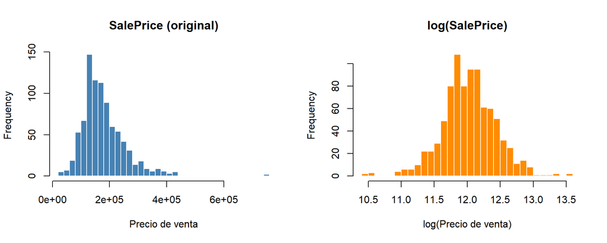

```r
# Comparamos visualmente la distribución original vs. la que usa logaritmo.
par(mfrow = c(1, 2))
hist(train$SalePrice, breaks = 40, col = "steelblue", border = "white",
     main = "SalePrice (original)", xlab = "Precio de venta")
hist(log(train$SalePrice), breaks = 40, col = "darkorange", border = "white",
     main = "log(SalePrice)", xlab = "log(Precio de venta)")
```

```r
par(mfrow = c(1, 1))
```

# 4 Análisis de valores faltantes

Es importante definir como tratamos los datos faltantes, porque muchos valores `NA` no son datos perdidos sino que la casa no tiene la característica (ejemplo una casa sin piscina tiene `PoolQC = NA`).

```r
# Contamos NA y cadenas vacías "".
contar_faltantes <- function(df) {
  na <- sapply(df, function(x) sum(is.na(x) | x == ""))
  na <- na[na > 0]
  data.frame(
    variable = names(na),
    n_faltantes = as.integer(na),
    pct = round(100 * as.integer(na) / nrow(df), 1),
    row.names = NULL
  ) %>% arrange(desc(n_faltantes))
}

faltantes_train <- contar_faltantes(train)
faltantes_train
```

```
##        variable n_faltantes  pct
## 1        PoolQC         875 99.4
## 2   MiscFeature         845 96.0
## 3         Alley         814 92.5
## 4         Fence         725 82.4
## 5   FireplaceQu         402 45.7
## 6   LotFrontage         166 18.9
## 7    GarageType          49  5.6
## 8   GarageYrBlt          49  5.6
## 9  GarageFinish          49  5.6
## 10   GarageQual          49  5.6
## 11   GarageCond          49  5.6
## 12 BsmtExposure          24  2.7
## 13     BsmtQual          23  2.6
## 14     BsmtCond          23  2.6
## 15 BsmtFinType1          23  2.6
## 16 BsmtFinType2          23  2.6
## 17   MasVnrType           6  0.7
## 18   MasVnrArea           6  0.7
## 19   Electrical           1  0.1
```

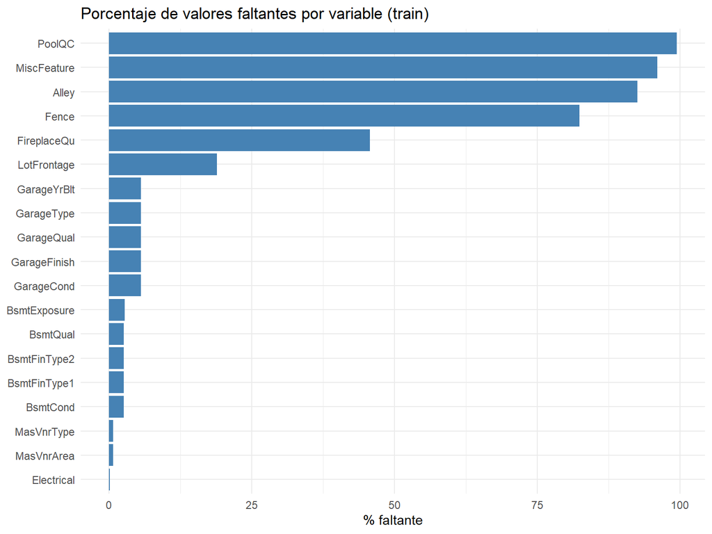

```r
# Visualizamos el porcentaje de faltantes por variable para priorizar el tratamiento.
ggplot(faltantes_train, aes(x = reorder(variable, pct), y = pct)) +
  geom_col(fill = "steelblue") +
  coord_flip() +
  labs(title = "Porcentaje de valores faltantes por variable (train)",
       x = NULL, y = "% faltante") +
  theme_minimal()
```

**Interpretación:**

- `PoolQC` (99.4% de faltantes), `MiscFeature`, `Alley`, `Fence`, `FireplaceQu`, y los bloques `Garage*` y `Bsmt*`: el `NA` significa que no tiene. → Se imputarán con una categoría explícita `"None"` (o 0 en sus áreas numéricas).
- `LotFrontage` (18.9%): faltante numérico genuino, usaremos la mediana de los datos dentro del mismo Neighborhood ya que las casas tendrian lotes similares.

# 5 Relación de las variables numéricas con el precio

```r
# Correlación de cada numérica con SalePrice.
# Sirve como primer filtro
num <- train[, tipos %in% c("numeric", "integer")]
num <- num[, !names(num) %in% "Id"]   # Id es un identificador, no aporta señal.
cors <- sapply(num[, names(num) != "SalePrice"], function(x) {
  if (all(is.na(x))) return(NA)
  cor(x, train$SalePrice, use = "complete.obs")
})
cor_df <- data.frame(variable = names(cors), correlacion = round(cors, 3)) %>%
  arrange(desc(abs(correlacion)))
head(cor_df, 15)
```

```
##                  variable correlacion
## OverallQual   OverallQual       0.791
## GrLivArea       GrLivArea       0.713
## TotalBsmtSF   TotalBsmtSF       0.654
## GarageCars     GarageCars       0.646
## X1stFlrSF       X1stFlrSF       0.625
## GarageArea     GarageArea       0.616
## FullBath         FullBath       0.574
## TotRmsAbvGrd TotRmsAbvGrd       0.542
## YearBuilt       YearBuilt       0.539
## YearRemodAdd YearRemodAdd       0.513
## GarageYrBlt   GarageYrBlt       0.499
## MasVnrArea     MasVnrArea       0.474
## Fireplaces     Fireplaces       0.460
## BsmtFinSF1     BsmtFinSF1       0.431
## LotFrontage   LotFrontage       0.414
```

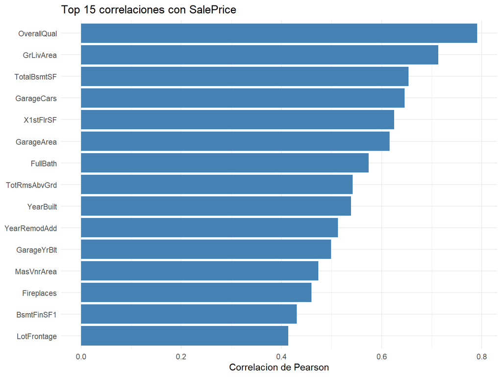

```r
# Graficamos las 15 numéricas más correlacionadas (en valor absoluto) con el precio.
top15 <- head(cor_df, 15)
ggplot(top15, aes(x = reorder(variable, correlacion), y = correlacion)) +
  geom_col(fill = "steelblue") +
  coord_flip() +
  labs(title = "Top 15 correlaciones con SalePrice", x = NULL, y = "Correlacion de Pearson") +
  theme_minimal()
```

Las predictoras más fuertes son `OverallQual` (calidad general, 0.79), `GrLivArea` (área habitable, 0.71), `TotalBsmtSF`, `GarageCars`/`GarageArea` y `X1stFlrSF`.

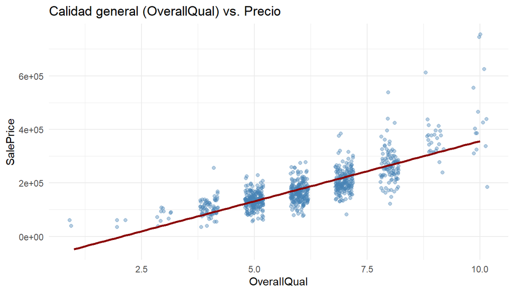

```r
# Relación más fuerte: calidad general vs. precio. Usamos jitter porque OverallQual
# es discreta (1-10) y así evitamos el solapamiento de puntos.
ggplot(train, aes(OverallQual, SalePrice)) +
  geom_jitter(alpha = 0.4, width = 0.2, color = "steelblue") +
  geom_smooth(method = "lm", se = FALSE, color = "darkred") +
  labs(title = "Calidad general (OverallQual) vs. Precio") + theme_minimal()
```

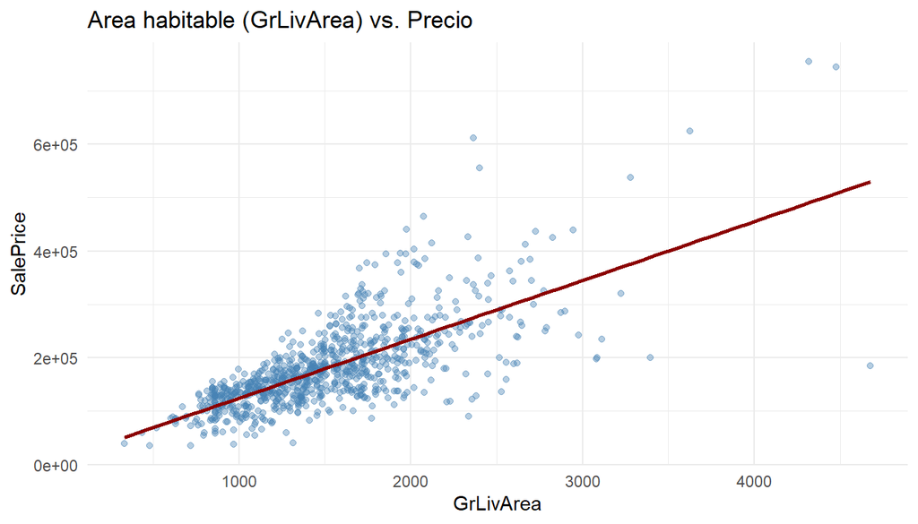

```r
# Segunda relación mas fuerte: área habitable vs. precio. Aquí se buscan
# outliers (puntos de área muy grande con precio bajo).
ggplot(train, aes(GrLivArea, SalePrice)) +
  geom_point(alpha = 0.4, color = "steelblue") +
  geom_smooth(method = "lm", se = FALSE, color = "darkred") +
  labs(title = "Area habitable (GrLivArea) vs. Precio") + theme_minimal()
```

# 6 Detección preliminar de outliers

Buscamos cosas como Casas muy grandes pero con precios bajos, entre otras.

```r
# Candidatos a outlier: área habitable muy grande con precio bajo.
train %>%
  filter(GrLivArea > 4000) %>%
  select(Id, GrLivArea, OverallQual, SalePrice) %>%
  arrange(desc(GrLivArea))
```

```
##     Id GrLivArea OverallQual SalePrice
## 1  524      4676          10    184750
## 2 1183      4476          10    745000
## 3  692      4316          10    755000
```

# 7 Variables categóricas: cardinalidad

```r
# Cardinalidad de variables categoricas
chars <- names(train)[tipos == "character"]
card <- sapply(chars, function(c) length(unique(train[[c]])))
data.frame(variable = names(card), n_niveles = as.integer(card)) %>%
  arrange(desc(n_niveles)) %>% head(15)
```

```
##        variable n_niveles
## 1  Neighborhood        25
## 2   Exterior2nd        15
## 3   Exterior1st        14
## 4    Condition1         9
## 5      SaleType         9
## 6    HouseStyle         8
## 7    Condition2         7
## 8  BsmtFinType1         7
## 9  BsmtFinType2         7
## 10   Functional         7
## 11   GarageType         7
## 12    RoofStyle         6
## 13   Foundation         6
## 14      Heating         6
## 15   Electrical         6
```

`Neighborhood` (25 niveles), `Exterior1st/2nd` (15) son las de mayor cardinalidad.

# 8 Conclusiones del EDA

1. **Objetivo:** modelar `log(SalePrice)` ya que esto ayuda a que la distribucion de datos sea mas simetrica.
2. **Faltantes estructurales:** la mayoría de `NA` significan “no tiene”. Solo `LotFrontage`, `MasVnr*` y `Electrical` son faltantes reales.
3. **Variables fuertes:** calidad (`OverallQual`) y superficie (`GrLivArea`, `TotalBsmtSF`, garaje) son las de mayor correlacion.
4. **Outliers:** revisar las viviendas con `GrLivArea > 4000` y precio bajo.
5. **Categóricas:** alta cardinalidad en `Neighborhood`/`Exterior*`

# 9 Limpieza y preprocesamiento

Hacemos una transformacion a todos los datos primero y luego volvemos a separar los datasets.

```r
# Añadimos un marcador para poder separar después
train_m <- train %>% mutate(is_train = 1L)
test_m  <- test  %>% mutate(is_train = 0L, SalePrice = NA_real_)

full <- bind_rows(train_m, test_m)
cat("Dataset combinado:", nrow(full), "filas x", ncol(full), "columnas\n")
```

```
## Dataset combinado: 1100 filas x 82 columnas
```

```r
# Unificamos cadenas vacías "" como NA en las columnas de texto, para tratar
# todos los faltantes
chars_all <- names(full)[sapply(full, is.character)]
full[chars_all] <- lapply(full[chars_all], function(x) ifelse(x == "", NA, x))
```

## 9.1 Imputación de faltantes estructurales (“no tiene”)

Según el diccionario de Ames, en estas variables el `NA` significa **ausencia** de la característica. Imputamos una categoría `"None"` para mantener esa información (una casa sin piscina da informacion importante).

```r
# Categóricas donde NA = "no tiene esa característica".
cat_none <- c("PoolQC", "MiscFeature", "Alley", "Fence", "FireplaceQu",
              "GarageType", "GarageFinish", "GarageQual", "GarageCond",
              "BsmtQual", "BsmtCond", "BsmtExposure", "BsmtFinType1", "BsmtFinType2",
              "MasVnrType")
for (v in cat_none) full[[v]][is.na(full[[v]])] <- "None"

# Numéricas asociadas a esas características
num_zero <- c("MasVnrArea", "BsmtFinSF1", "BsmtFinSF2", "BsmtUnfSF", "TotalBsmtSF",
              "BsmtFullBath", "BsmtHalfBath", "GarageCars", "GarageArea")
for (v in num_zero) full[[v]][is.na(full[[v]])] <- 0
```

## 9.2 Imputación de faltantes genuinos

```r
# cuando GarageYrBlt es NA asumimos que fue construido cuando se construyo la casa, poner 0 seria un dato incorrecto
full$GarageYrBlt[is.na(full$GarageYrBlt)] <- full$YearBuilt[is.na(full$GarageYrBlt)]

# LotFrontage (frente de lote): faltante real. El frente es consistente dentro de un
#    mismo vecindario, así que imputamos con la MEDIANA por Neighborhood
full <- full %>%
  group_by(Neighborhood) %>%
  mutate(LotFrontage = ifelse(is.na(LotFrontage),
                              median(LotFrontage, na.rm = TRUE), LotFrontage)) %>%
  ungroup()
full$LotFrontage[is.na(full$LotFrontage)] <- median(full$LotFrontage, na.rm = TRUE)

# Electrical: 1 solo faltante, solo le agregamos la moda al ser un dato no es tan importante.
moda <- function(x) names(sort(table(x), decreasing = TRUE))[1]
full$Electrical[is.na(full$Electrical)] <- moda(full$Electrical)
```

```r
# Verificación
na_restantes <- sapply(full, function(x) sum(is.na(x)))
na_restantes <- na_restantes[na_restantes > 0]
na_restantes
```

```
## SalePrice
##       220
```

## 9.3 Tratamiento de outliers

Del EDA, las casas con `GrLivArea > 4000`: una casa definitamente es outlier (la de Id 524: 4676 pies² pero con precio $184,750, esta casa no representa el mercado). Eliminamos solo ese caso del dataset de train para no afectar al modelo

```r
# Eliminamos la venta anómala Id 524
n_antes <- sum(full$is_train == 1)
full <- full %>% filter(!(is_train == 1 & Id == 524))
cat("Filas de train antes:", n_antes, "-> después:", sum(full$is_train == 1), "\n")
```

```
## Filas de train antes: 880 -> después: 879
```

## 9.4 Ingeniería de variables

Creamos variables que pueden ayudar al modelo

```r
full <- full %>% mutate(
  # Superficie total habitable: sótano + 1er + 2do piso. Resume el tamaño en una sola
  # variable muy correlacionada con el precio.
  TotalSF       = TotalBsmtSF + X1stFlrSF + X2ndFlrSF,
  # Total de baños (los de sótano cuentan como 0.5 los medios baños).
  TotalBaths    = FullBath + 0.5 * HalfBath + BsmtFullBath + 0.5 * BsmtHalfBath,
  # Antiguedad de la casa al momento de la venta y años desde la última remodelación.
  HouseAge      = YrSold - YearBuilt,
  RemodAge      = YrSold - YearRemodAdd,
  # Porche total y bandera de remodelación (1 si se remodeló después de construida).
  TotalPorchSF  = OpenPorchSF + EnclosedPorch + X3SsnPorch + ScreenPorch + WoodDeckSF,
  Remodelada    = ifelse(YearRemodAdd > YearBuilt, 1L, 0L),
  # Banderas de presencia (señal simple y robusta).
  TienePiscina  = ifelse(PoolArea > 0, 1L, 0L),
  TieneGaraje   = ifelse(GarageArea > 0, 1L, 0L),
  TieneSotano   = ifelse(TotalBsmtSF > 0, 1L, 0L),
  Tiene2doPiso  = ifelse(X2ndFlrSF > 0, 1L, 0L)
)

# Arreglamos una inconsistencia de los datos (YrSold < YearBuilt) por errores
# de captura y les ponemos 0
full$HouseAge[full$HouseAge < 0] <- 0
full$RemodAge[full$RemodAge < 0] <- 0

cat("Nuevas variables creadas. Total de columnas ahora:", ncol(full), "\n")
```

```
## Nuevas variables creadas. Total de columnas ahora: 92
```

## 9.5 Codificación de categóricas y separación final

```r
# Convertimos todas las variables de texto a factor
chars_final <- names(full)[sapply(full, is.character)]
full[chars_final] <- lapply(full[chars_final], factor)

# Separamos de nuevo en train y test limpios.
train_clean <- full %>% filter(is_train == 1) %>% select(-is_train)
test_clean  <- full %>% filter(is_train == 0) %>% select(-is_train, -SalePrice)

cat("train_clean:", nrow(train_clean), "x", ncol(train_clean), "\n")
```

```
## train_clean: 879 x 91
```

```r
cat("test_clean :", nrow(test_clean),  "x", ncol(test_clean),  "\n")
```

```
## test_clean : 220 x 90
```

```r
# Guardamos los datasets limpios para reutilizarlos en el modelado.
saveRDS(train_clean, "train_clean.rds")
saveRDS(test_clean,  "test_clean.rds")
```

# 10 Conclusiones de la limpieza

- **Faltantes resueltos**: Verificamos que no quedan `NA`.
- **Outlier anómalo** (Id 524) eliminado solo del train.
- **Nuevas variables** superficie total, baños totales, antigüedad, banderas
- **Categóricas codificadas** consistentemente entre train y test.

# 11 Modelado

Usamos una regresión lineal como base, y regularización Ridge , Lasso , Elastic-Net** (`glmnet`), evaluadas con cross validation usando **RMSE** como metrica

```r
library(glmnet)
set.seed(2026)
```

## 11.1 Preparación: objetivo, matriz de diseño y función de error

```r
# SalePrice (variable y) como logaritmo
y <- log(train_clean$SalePrice)

# Predictoras: quitamos Id  y SalePrice
pred_train <- train_clean %>% select(-Id, -SalePrice)
pred_test  <- test_clean  %>% select(-Id)

# Construimos una matriz de diseño
combined <- bind_rows(pred_train, pred_test)
X_all   <- model.matrix(~ ., data = combined)[, -1]   # [,-1] elimina el intercepto.
X_train <- X_all[1:nrow(pred_train), ]
X_test  <- X_all[(nrow(pred_train) + 1):nrow(X_all), ]
cat("Matriz de diseño X_train:", nrow(X_train), "filas x", ncol(X_train), "columnas\n")
```

```
## Matriz de diseño X_train: 879 filas x 264 columnas
```

```r
# RMSE en su escala original ya que las predicciones se hacen en log, así que exponenciamos antes
# de comparar contra el precio real
rmse_orig <- function(pred_log, actual_orig) {
  sqrt(mean((exp(pred_log) - actual_orig)^2))
}

# Validación cruzada K-fold Definimos los folds una sola vez para comparar
# todos los modelos sobre las mismas particiones
K <- 5
folds <- sample(rep(1:K, length.out = nrow(X_train)))

# recibe una función que ajusta y predice, y devuelve el RMSE por fold.
cv_rmse <- function(fit_predict) {
  out <- numeric(K)
  for (k in 1:K) {
    tr <- which(folds != k); va <- which(folds == k)
    pred_log <- fit_predict(X_train[tr, ], y[tr], X_train[va, ])
    out[k] <- rmse_orig(pred_log, train_clean$SalePrice[va])
  }
  out
}
```

## 11.2 Modelo base: regresión lineal (OLS)

```r
# OLS sobre todas las predictoras. Es nuestra línea base de referencia
ols <- function(Xtr, ytr, Xva) {
  df <- data.frame(y = ytr, Xtr); colnames(df) <- c("y", colnames(Xtr))
  m  <- lm(y ~ ., data = df)
  nd <- data.frame(Xva); colnames(nd) <- colnames(Xtr)
  as.numeric(predict(m, nd))
}
r_ols <- cv_rmse(ols)
cat(sprintf("OLS — RMSE CV: %.0f (sd %.0f)\n", mean(r_ols), sd(r_ols)))
```

```
## OLS — RMSE CV: 28489 (sd 7134)
```

el modelo de regresion lineal OLS sobreajusta, ya que su RMSE de validación es alto y muy variable.

## 11.3 Modelos regularizados: Ridge, Lasso y Elastic-Net

```r
glm_fit <- function(alpha) function(Xtr, ytr, Xva) {
  cv <- cv.glmnet(Xtr, ytr, alpha = alpha, nfolds = 5)
  as.numeric(predict(cv, newx = Xva, s = "lambda.min"))
}

alphas <- c(0, 0.25, 0.5, 0.75, 1)
resultados <- lapply(alphas, function(a) {
  r <- cv_rmse(glm_fit(a))
  data.frame(alpha = a, RMSE = mean(r), sd = sd(r))
})
tabla_glm <- do.call(rbind, resultados)
tabla_glm$modelo <- c("Ridge", "Elastic-Net", "Elastic-Net", "Elastic-Net", "Lasso")
tabla_glm[, c("modelo", "alpha", "RMSE", "sd")]
```

```
##        modelo alpha     RMSE       sd
## 1       Ridge  0.00 23738.64 2620.748
## 2 Elastic-Net  0.25 22251.94 2575.036
## 3 Elastic-Net  0.50 22011.61 2741.872
## 4 Elastic-Net  0.75 22050.87 2763.025
## 5       Lasso  1.00 22104.63 2625.128
```

```r
# Tabla comparativa final
comparacion <- rbind(
  data.frame(modelo = "OLS", alpha = NA, RMSE = mean(r_ols), sd = sd(r_ols)),
  tabla_glm[, c("modelo", "alpha", "RMSE", "sd")]
)
comparacion <- comparacion %>% arrange(RMSE)
comparacion
```

```
##        modelo alpha     RMSE       sd
## 1 Elastic-Net  0.50 22011.61 2741.872
## 2 Elastic-Net  0.75 22050.87 2763.025
## 3       Lasso  1.00 22104.63 2625.128
## 4 Elastic-Net  0.25 22251.94 2575.036
## 5       Ridge  0.00 23738.64 2620.748
## 6         OLS    NA 28489.39 7133.672
```

```r
# Elegimos el mejor alpha (menor RMSE de validación).
mejor_alpha <- tabla_glm$alpha[which.min(tabla_glm$RMSE)]
cat("Mejor alpha (Elastic-Net):", mejor_alpha, "\n")
```

```
## Mejor alpha (Elastic-Net): 0.5
```

[figure not shown]

```r
# Visualizamos el RMSE por modelo
ggplot(comparacion, aes(x = reorder(modelo, -RMSE), y = RMSE)) +
  geom_col(fill = "steelblue") +
  geom_text(aes(label = round(RMSE)), vjust = -0.3, size = 3) +
  labs(title = "RMSE de validacion cruzada por modelo",
       x = NULL, y = "RMSE (escala original, USD)") +
  theme_minimal()
```

La regularización reduce el RMSE de ~28,500 (OLS base) a ~22,100. El Elastic-Net obtiene el mejor resultado

## 11.4 Selección de variables embebida (Lasso)

```r
# El Lasso realiza selección de variables embebida lleva coeficientes a 0.
# Ajustamos sobre todo el train para ver cuántas variables retiene el modelo.
cv_lasso <- cv.glmnet(X_train, y, alpha = 1, nfolds = 5)
coefs <- coef(cv_lasso, s = "lambda.min")
n_total <- nrow(coefs) - 1                 # -1 por el intercepto
n_activas <- sum(coefs[-1, 1] != 0)
cat("Variables disponibles:", n_total, "| seleccionadas por Lasso:", n_activas,
    sprintf("(%.0f%% descartadas)\n", 100 * (1 - n_activas / n_total)))
```

```
## Variables disponibles: 264 | seleccionadas por Lasso: 111 (58% descartadas)
```

El Lasso descarta automáticamente las variables irrelevantes, dejando un modelo más simple e interpretable.